# Possessive Dative im Deutschen Textarchiv

Autor:in

Andreas Blombach, Bettina Lindner-Bornemann

Dieses Dokument enthält Analysen für unseren Artikel (Lindner-Bornemann und Blombach 2023), die hier zum Teil etwas ausführlicher ausfallen.

```r
library(tidyverse)
library(tidytable)
library(yardstick)
library(readxl)
library(irr)
library(patchwork)
library(scales)
```

```r
# bereits annotierte Excel-Dateien einlesen:
ann_a <- read_xlsx("data/annotation_a_sample.xlsx",
                     col_types = c("text", "text", "text", "text", "text",
                                   "text", "text", "text", "text", "text",
                                   "text", "text", "text", "text", "text",
                                   "text", "guess", "text", "text", "text",
                                   "text", "text", "text", "text"))
ann_a <- ann_a %>%
  mutate(textClassDTA = replace_na(textClassDTA, ""),
         textClass = replace_na(textClass, ""))
ann_b <- read_xlsx("data/annotation_b_sample.xlsx",
                     col_types = c("text", "text", "text", "text", "text",
                                   "text", "text", "text", "text", "text",
                                   "text", "text", "text", "text", "text",
                                   "text", "guess", "text", "text", "text",
                                   "text", "text", "text", "text"))
ann_b <- ann_b %>%
  mutate(textClassDTA = replace_na(textClassDTA, ""),
         textClass = replace_na(textClass, ""))

combined <- ann_a |>
  inner_join(ann_b,
             by = c("match", "sentence", "pos_before", "pos_after", "token1",
                    "token2", "token3", "date", "collection", "author",
                    "title", "textClass", "bibl", "textClassDTA"))
```

Stichprobe, adjudizierte Annotation:

```r
gold <- read_excel("data/annotation_gold_sample.xlsx")
```

## Inter-Annotator-Agreement

Annotierte Kategorien bei Annotator A:

```r
ann_a |>
  mutate.(cat = factor(cat,
                       levels = c("dp", "dpe", "aj", "a", "an",
                                  "agp/dp", "gp/dp", "gpe/dpe",
                                  "agp", "gp", "gpe", "na", "n"),
                       labels = c("dp: Dativus possessivus",
                                  "dpe: Dat. poss. mit Ellipse",
                                  "aj: synt. mehrdeutig, Tendenz zu Dat.",
                                  "a: syntaktisch mehrdeutig",
                                  "an: synt. mehrdeutig, Tendenz zu nein",
                                  "agp/dp: synt. mehrdeutig; Gen./Dat. poss.",
                                  "gp/dp: Gen./Dat. poss.",
                                  "gpe/dpe: Gen./Dat. poss. mit Ellipse",
                                  "agp: synt. mehrdeutig, evtl. Gen. poss.",
                                  "gp: Genitivus possessivus",
                                  "gpe: Gen. poss. mit Elipse",
                                  "na: nein, aber",
                                  "n: nein"
                                  ))) |>
  pull(cat) |>
  fct_count(sort = TRUE) |>
  mutate(percentage = n / sum(n) * 100)
```

| f | n | percentage |
| --- | --- | --- |
| n: nein | 6702 | 88.58049167 |
| na: nein, aber | 270 | 3.56859635 |
| gp: Genitivus possessivus | 225 | 2.97383029 |
| gpe: Gen. poss. mit Elipse | 79 | 1.04414486 |
| a: syntaktisch mehrdeutig | 72 | 0.95162569 |
| an: synt. mehrdeutig, Tendenz zu nein | 62 | 0.81945546 |
| gp/dp: Gen./Dat. poss. | 62 | 0.81945546 |
| aj: synt. mehrdeutig, Tendenz zu Dat. | 38 | 0.50224689 |
| dp: Dativus possessivus | 32 | 0.42294475 |
| agp/dp: synt. mehrdeutig; Gen./Dat. poss. | 10 | 0.13217024 |

[output cut: 3 more lines]

Annotierte Kategorien bei Annotator B:

```r
ann_b |>
  mutate.(cat = factor(cat,
                       levels = c("dp", "dpe", "aj", "a", "an",
                                  "agp/dp", "gp/dp", "gpe/dpe",
                                  "agp", "gp", "gpe", "na", "n"),
                       labels = c("dp: Dativus possessivus",
                                  "dpe: Dat. poss. mit Ellipse",
                                  "aj: synt. mehrdeutig, Tendenz zu Dat.",
                                  "a: syntaktisch mehrdeutig",
                                  "an: synt. mehrdeutig, Tendenz zu nein",
                                  "agp/dp: synt. mehrdeutig; Gen./Dat. poss.",
                                  "gp/dp: Gen./Dat. poss.",
                                  "gpe/dpe: Gen./Dat. poss. mit Ellipse",
                                  "agp: synt. mehrdeutig, evtl. Gen. poss.",
                                  "gp: Genitivus possessivus",
                                  "gpe: Gen. poss. mit Elipse",
                                  "na: nein, aber",
                                  "n: nein"
                                  ))) |>
  pull(cat) |>
  fct_count(sort = TRUE) |>
  mutate(percentage = n / sum(n) * 100)
```

| f | n | percentage |
| --- | --- | --- |
| n: nein | 6936 | 91.67327518 |
| gp: Genitivus possessivus | 229 | 3.02669839 |
| a: syntaktisch mehrdeutig | 106 | 1.40100449 |
| dp: Dativus possessivus | 94 | 1.24240021 |
| gp/dp: Gen./Dat. poss. | 86 | 1.13666402 |
| gpe: Gen. poss. mit Elipse | 54 | 0.71371927 |
| na: nein, aber | 31 | 0.40972773 |
| an: synt. mehrdeutig, Tendenz zu nein | 12 | 0.15860428 |
| gpe/dpe: Gen./Dat. poss. mit Ellipse | 12 | 0.15860428 |
| aj: synt. mehrdeutig, Tendenz zu Dat. | 4 | 0.05286809 |

[output cut: 3 more lines]

Übereinstimmung hierbei, wobei `"n"` (“nein”) und `"na"` (“nein, aber”) zusammengefasst werden[^1]:

```r
combined |>
  mutate(cat.x = ifelse(cat.x == "na", "n", cat.x),
         cat.y = ifelse(cat.y == "na", "n", cat.y)) |>
  select(cat.x, cat.y) |>
  agree()
```

```
 Percentage agreement (Tolerance=0)

 Subjects = 7566
   Raters = 2
  %-agree = 96.4
```

Cohens Kappa:

```r
combined |>
  mutate(cat.x = ifelse(cat.x == "na", "n", cat.x),
         cat.y = ifelse(cat.y == "na", "n", cat.y)) |>
  select(cat.x, cat.y) |>
  kappa2()
```

```
 Cohen's Kappa for 2 Raters (Weights: unweighted)

 Subjects = 7566
   Raters = 2
    Kappa = 0.758

        z = 107
  p-value = 0
```

Ein Wert von 0,76 gilt als beachtliche Übereinstimmung.

Gewichtet man diese Matrix nach Ähnlichkeit der Labels (Cohen 1968; Fleiss, Cohen, und Everitt 1969), erhält man ein noch höheres Kappa (die genaue Gewichtung enthält natürlich ein Element der Willkür):

```r
conf_mat <- combined |>
  mutate.(cat.x = cat.x |> factor(levels = c("dp", "dpe", "aj", "a", "an",
                                             "gp/dp", "gpe/dpe", "agp/dp",
                                             "gp", "gpe", "agp", "na", "n")),
          cat.y = cat.y |> factor(levels = c("dp", "dpe", "aj", "a", "an",
                                             "gp/dp", "gpe/dpe", "agp/dp",
                                             "gp", "gpe", "agp", "na", "n"))) |>
  select.(cat.x, cat.y) |>
  table()

# 13x13 Matrix -> entsprechende Gewichtsmatrix
# 1: perfekte Übereinstimmung, 0.8: 80% Übereinstimmung, usw.
weight_mat <- matrix(c(1, .8, .8, .6, .4, .4, .4, .4, .2, .2, .2, .2, 0,
                       .8, 1, .8, .6, .4, .4, .6, .4, .2, .4, .2, .2, 0,
                       .8, .8, 1, .8, .6, .6, .6, .4, .2, .2, .2, .4, .2,
                       .6, .6, .8, 1, .8, .6, .6, .4, .2, .2, .2, .6, .4,
                       .4, .4, .6, .8, 1, .6, .6, .4, .2, .2, .2, .8, .6,
                       .4, .4, .6, .6, .6, 1, .8, .8, .8, .8, .6, .8, .4,
                       .4, .6, .6, .6, .6, .8, 1, .6, .4, .8, .4, .6, .4,
                       .4, .4, .4, .4, .4, .8, .6, 1, .6, .6, .8, .6, .4,
                       .2, .2, .2, .2, .2, .8, .4, .6, 1, .8, .8, .2, .2,
                       .2, .4, .2, .2, .2, .8, .8, .6, .8, 1, .6, 0, .2,
                       .2, .2, .2, .2, .2, .6, .4, .8, .8, .6, 1, .2, .4,
                       .2, .2, .4, .6, .8, .8, .6, .6, .2, 0, .2, 1, 1,
                       0, 0, .2, .4, .6, .4, .4, .4, .2, .2, .4, 1, 1),
                     nrow = 13, ncol = 13)

conf_mat |> DescTools::CohenKappa(weights = weight_mat)
```

```
[1] 0.8640095
```

Übereinstimmung bei den Belegen, für die von mindestens einem Annotator etwas anderes als “n” oder “na” annotiert wurde:

```r
combined |>
  mutate(cat.x = ifelse(cat.x == "na", "n", cat.x),
         cat.y = ifelse(cat.y == "na", "n", cat.y)) |>
  filter(!(cat.x == "n" & cat.y == "n")) |>
  select(cat.x, cat.y) |>
  agree()
```

```
 Percentage agreement (Tolerance=0)

 Subjects = 661
   Raters = 2
  %-agree = 58.4
```

```r
combined |>
  mutate(cat.x = ifelse(cat.x == "na", "n", cat.x),
         cat.y = ifelse(cat.y == "na", "n", cat.y)) |>
  filter(!(cat.x == "n" & cat.y == "n")) |>
  select(cat.x, cat.y) |>
  kappa2()
```

```
 Cohen's Kappa for 2 Raters (Weights: unweighted)

 Subjects = 661
   Raters = 2
    Kappa = 0.495

        z = 31.2
  p-value = 0
```

Ein Wert von 0,5 gilt nach Cohen als moderate Übereinstimmung.

Gewichtetes Kappa hierfür:

```r
conf_mat <- combined |>
  filter(!(cat.x %chin% c("n", "na") & cat.y %chin% c("n", "na"))) |>
  mutate.(cat.x = cat.x |> factor(levels = c("dp", "dpe", "aj", "a", "an",
                                             "gp/dp", "gpe/dpe", "agp/dp",
                                             "gp", "gpe", "agp", "na", "n")),
          cat.y = cat.y |> factor(levels = c("dp", "dpe", "aj", "a", "an",
                                             "gp/dp", "gpe/dpe", "agp/dp",
                                             "gp", "gpe", "agp", "na", "n"))) |>
  select.(cat.x, cat.y) |>
  table()

# 13x13 Matrix -> entsprechende Gewichtsmatrix
# 1: perfekte Übereinstimmung, 0.8: 80% Übereinstimmung, usw.
weight_mat <- matrix(c(1, .8, .8, .6, .4, .4, .4, .4, .2, .2, .2, .2, 0,
                       .8, 1, .8, .6, .4, .4, .6, .4, .2, .4, .2, .2, 0,
                       .8, .8, 1, .8, .6, .6, .6, .4, .2, .2, .2, .4, .2,
                       .6, .6, .8, 1, .8, .6, .6, .4, .2, .2, .2, .6, .4,
                       .4, .4, .6, .8, 1, .6, .6, .4, .2, .2, .2, .8, .6,
                       .4, .4, .6, .6, .6, 1, .8, .8, .8, .8, .6, .8, .4,
                       .4, .6, .6, .6, .6, .8, 1, .6, .4, .8, .4, .6, .4,
                       .4, .4, .4, .4, .4, .8, .6, 1, .6, .6, .8, .6, .4,
                       .2, .2, .2, .2, .2, .8, .4, .6, 1, .8, .8, .2, .2,
                       .2, .4, .2, .2, .2, .8, .8, .6, .8, 1, .6, 0, .2,
                       .2, .2, .2, .2, .2, .6, .4, .8, .8, .6, 1, .2, .4,
                       .2, .2, .4, .6, .8, .8, .6, .6, .2, 0, .2, 1, 1,
                       0, 0, .2, .4, .6, .4, .4, .4, .2, .2, .4, 1, 1),
                     nrow = 13, ncol = 13)

conf_mat |> DescTools::CohenKappa(weights = weight_mat)
```

```
[1] 0.6327625
```

Konfusionsmatrix/Kreuztabelle:

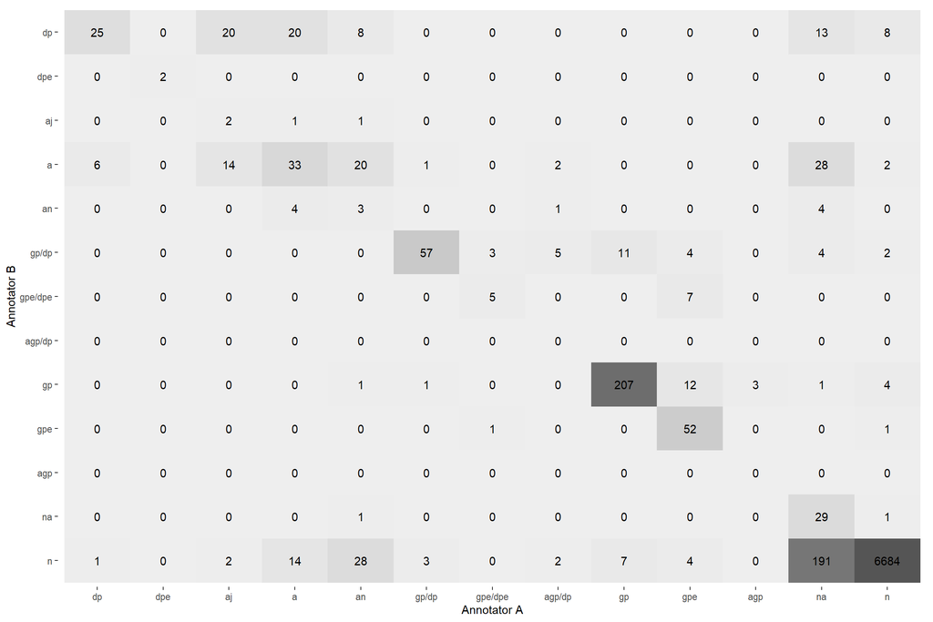

```r
confmat <- combined |>
  mutate.(cat.x = cat.x |> factor(levels = c("dp", "dpe", "aj", "a", "an",
                                             "gp/dp", "gpe/dpe", "agp/dp",
                                             "gp", "gpe", "agp", "na", "n")),
          cat.y = cat.y |> factor(levels = c("dp", "dpe", "aj", "a", "an",
                                             "gp/dp", "gpe/dpe", "agp/dp",
                                             "gp", "gpe", "agp", "na", "n"))) |>
  select.(cat.x, cat.y) |>
  conf_mat(truth = cat.x, estimate = cat.y,
           dnn = c("Annotator B", "Annotator A"))

confmat |>
  autoplot(cm, type = "heatmap") +
  scale_fill_gradient(low = "#EEEEEE",
                      high = "#555555",
                      limits = c(NA, 250), oob = oob_squish)
```

## DTA-Korpus (insgesamt)

Das Deutsche Textarchiv ist nicht balanciert (was sich durch den Einbezug der Erweiterungen wahrscheinlich noch verstärkt). Das gilt es bei der Analyse der absoluten Häufigkeiten zu berücksichtigen.

Wir fassen unsere Belege daher in 50-Jahres-Intervallen zusammen und normalisieren die Häufigkeiten anhand der Gesamttokenmengen in diesen Intervallen.

Wie man an diesen Gesamttokenmengen sehen kann, gibt es im DTA aktuell nur sehr wenige Texte von vor 1600, während das 19. Jahrhundert stark überrepräsentiert ist. Die sehr wenigen Texte aus dem 20. Jahrhundert fallen nicht ins Gewicht (und sollten wahrscheinlich eigentlich gar nicht im Korpus enthalten sein).

Auch die Verteilung auf die vier Haupttextgenres fällt über die Zeit sehr unterschiedlich aus (man beachte bspw. den Einbruch der Gebrauchsliteratur zwischen 1750 und 1850).

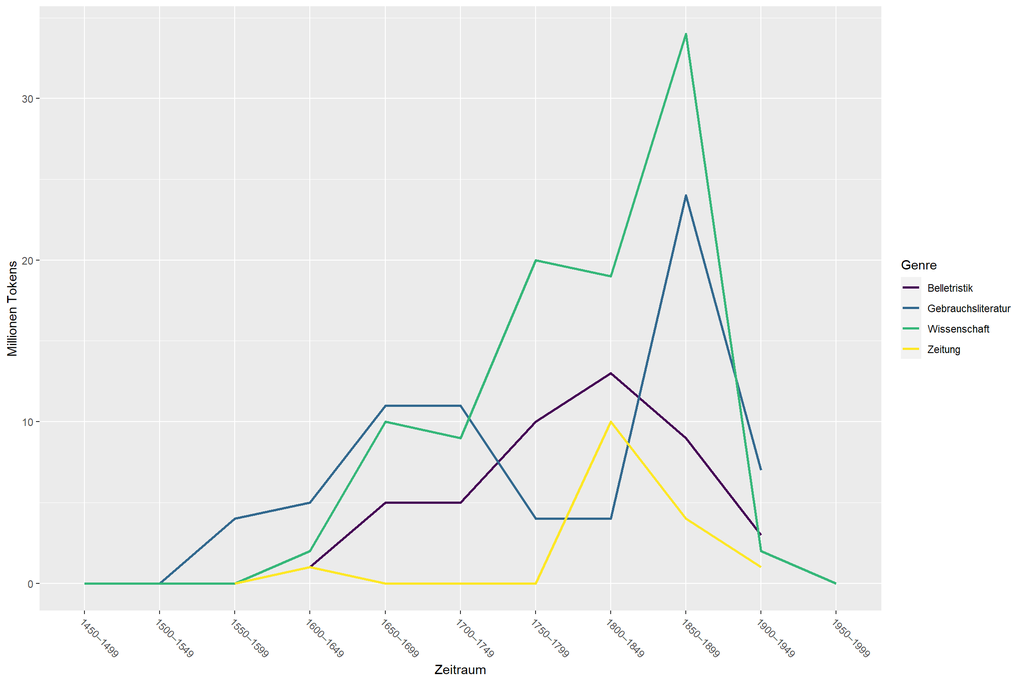

```r
cnts <- readRDS("data/dta_cnts_genre_year.RDS")
levels(cnts$Date_50) <- c("1450–1499", "1500–1549",
                          "1550–1599", "1600–1649",
                          "1650–1699", "1700–1749",
                          "1750–1799", "1800–1849",
                          "1850–1899", "1900–1949",
                          "1950–1999")

cnts2 <- cnts %>% group_by(Date_50, First_genre) %>%
  summarise(Count = sum(Count))

options(scipen = 999)
cnts2 %>%
  mutate.(Count = Count / 1e6) %>%
  drop_na.() %>%
  ggplot(aes(x = Date_50, y = Count,
                     colour = First_genre, group = First_genre)) +
  geom_line(size = 1) +
  theme(axis.text.x = element_text(angle = -45, hjust = 0)) +
  labs(x = "Zeitraum", y = "Millionen Tokens", colour = "Genre") +
  scale_color_viridis_d()
```

## Analyse der adjudizierten Daten (Golddaten)

Wie oft wurde jede Kategorie vergeben?

```r
gold |>
  mutate.(cat = factor(cat,
                       levels = c("dp", "dpe", "aj", "a", "an",
                                  "agp/dp", "gp/dp", "gpe/dpe",
                                  "agp", "gp", "gpe", "na", "n"),
                       labels = c("dp: Dativus possessivus",
                                  "dpe: Dat. poss. mit Ellipse",
                                  "aj: synt. mehrdeutig, Tendenz zu Dat.",
                                  "a: syntaktisch mehrdeutig",
                                  "an: synt. mehrdeutig, Tendenz zu nein",
                                  "agp/dp: synt. mehrdeutig; Gen./Dat. poss.",
                                  "gp/dp: Gen./Dat. poss.",
                                  "gpe/dpe: Gen./Dat. poss. mit Ellipse",
                                  "agp: synt. mehrdeutig, evtl. Gen. poss.",
                                  "gp: Genitivus possessivus",
                                  "gpe: Gen. poss. mit Elipse",
                                  "na: nein, aber",
                                  "n: nein"
                                  ))) |>
  pull(cat) |>
  fct_count(sort = TRUE) |>
  mutate.(percentage = n / sum(n) * 100)
```

| f | n | percentage |
| --- | --- | --- |
| n: nein | 6704 | 88.60692572 |
| na: nein, aber | 260 | 3.43642612 |
| gp: Genitivus possessivus | 218 | 2.88131113 |
| a: syntaktisch mehrdeutig | 79 | 1.04414486 |
| gpe: Gen. poss. mit Elipse | 77 | 1.01771081 |
| gp/dp: Gen./Dat. poss. | 63 | 0.83267248 |
| an: synt. mehrdeutig, Tendenz zu nein | 58 | 0.76658736 |
| aj: synt. mehrdeutig, Tendenz zu Dat. | 43 | 0.56833201 |
| dp: Dativus possessivus | 29 | 0.38329368 |
| agp/dp: synt. mehrdeutig; Gen./Dat. poss. | 17 | 0.22468940 |

[output cut: 3 more lines]

Vor 1550 gibt es nur zwei Belege (aus derselben Quelle von 1465), die mit einer relevanten Kategorie annotiert wurden (allerdings beide als possessive Dative!), weshalb wir diese in den folgenden Zeitverlaufsgraphiken ausblenden:

```r
gold |>
  filter.(date < 1550 & !cat %chin% c("n", "na"))
```

| match | cat | genus_possessor | genus_possessum | numerus_possessor | numerus_possessum | animacy_possessor | animacy_possessum | sentence | pos_before | pos_after | token1 | token2 | token3 | date | collection | author | title | textClass | bibl | textClassDTA | comment |
| --- | --- | --- | --- | --- | --- | --- | --- | --- | --- | --- | --- | --- | --- | --- | --- | --- | --- | --- | --- | --- | --- |
| den Frauen ihr | dp | f | f | p | p | menschlich | konkret | Zw dem dritten mal ist ain frag vnd dubium , warvmb --->den frawen jr<--- wochen , das ist dy vbrig fewchtikayt , dy jr natur nit bedewen vnd verprawchen mag , alle monat flyssen vnd nit in den mannen… | PWAV | NN | den | Frauen | ihr | 1465 | dtae | Hartlieb, Johann (#118546201) | ›Secreta mulierum‹ mit Glosse in der deutschen Bearbeitung von Johann Hartlieb (1465): Text und Untersuchungen | Wissenschaft::Naturwissenschaft | ›Secreta mulierum‹ mit Glosse in der deutschen Bearbeitung von Johann Hartlieb (1465). Hg. von Kristian Bosselmann-Cyran. Pattensen (Hannover), 1985. | NA | NA |
| den Frauen ihr | dp | f | f | p | s | menschlich | abstrakt | Von wannen --->den frawen jr<--- natur kwmm in der mynn , so sy schwanger sein vnd so dy mueter beschlossen ist | ADV | NN | den | Frauen | ihr | 1465 | dtae | Hartlieb, Johann (#118546201) | ›Secreta mulierum‹ mit Glosse in der deutschen Bearbeitung von Johann Hartlieb (1465): Text und Untersuchungen | Wissenschaft::Naturwissenschaft | ›Secreta mulierum‹ mit Glosse in der deutschen Bearbeitung von Johann Hartlieb (1465). Hg. von Kristian Bosselmann-Cyran. Pattensen (Hannover), 1985. | NA | NA |

```r
gold |>
  filter.(date < 1550 & !cat %chin% c("n", "na")) |>
  pull(sentence)
```

```
[1] "Zw dem dritten mal ist ain frag vnd dubium , warvmb --->den frawen jr<--- wochen , das ist dy vbrig fewchtikayt , dy jr natur nit bedewen vnd verprawchen mag , alle monat flyssen vnd nit in den mannen , dye doch auch vbrig fewchtikayt haben , darauß denn jdem man natur vnd sperma wirt , das auc…
[2] "Von wannen --->den frawen jr<--- natur kwmm in der mynn , so sy schwanger sein vnd so dy mueter beschlossen ist"
```

Ebenso blenden wir vier Belege ab 1900 aus (ein possessiver Dativ, drei syntaktisch ambige Sätze); wie oben erwähnt, gibt es kaum Texte aus dieser Zeit im DTA. Die Entfernung all dieser Belege erleichtert die Interpretation der Zeitverlaufsgraphiken.

```r
gold |>
  filter.(date >= 1900 & !cat %chin% c("n", "na"))
```

| match | cat | genus_possessor | genus_possessum | numerus_possessor | numerus_possessum | animacy_possessor | animacy_possessum | sentence | pos_before | pos_after | token1 | token2 | token3 | date | collection | author | title | textClass | bibl | textClassDTA | comment |
| --- | --- | --- | --- | --- | --- | --- | --- | --- | --- | --- | --- | --- | --- | --- | --- | --- | --- | --- | --- | --- | --- |
| dem Dichter sein | a | m | m | s | s | menschlich | abstrakt | In den beiden Schlußstrophen des Gedichtes " Das Ideal und das Leben " , das in seiner Ganzheit nicht voll gelungen ist und um das er verschiedentlich gerungen hat , ist --->dem Dichter sein<--- Liebl… | VAFIN | NN | dem | Dichter | sein | 1959 | dtae | Seidler, Herbert (#118760645) | Die Dichtung: Wesen, Form, Dasein | Wissenschaft::Literaturwissenschaft | Seidler, Herbert: Die Dichtung: Wesen, Form, Dasein. Stuttgart, 1959. | NA | NA |
| dem Jungen sein | dp | m | n | s | s | menschlich | konkret (Körperteil) | Ich führ' selbst in die Grube , wenn ich --->dem Jungen sein<--- todt Gesicht noch länger ansehen sollte . | PPER | ADJD | dem | Jungen | sein | 1910 | dtae | Storm, Theodor (#118618725) | Eine Malerarbeit | Belletristik::Novelle | Storm, Theodor: Eine Malerarbeit. In: Deutscher Novellenschatz. Hrsg. von Paul Heyse und Hermann Kurz. Bd. 9. 2. Aufl. Berlin, [1910], S. 257–304. In: Weitin, Thomas (Hrsg.): Volldigitalisiertes Korpu… | NA | NA |
| jedem Menschen sein | a | m | m | s | s | menschlich | abstrakt | So war --->jedem Menschen sein<--- Wert von der Geburt an bestimmt , ganz gleichgültig , welchen Wert er dann in Wirklichkeit für seine Angehörigen repräsentierte . | VAFIN | NN | jedem | Menschen | sein | 1900 | dtak | Simmel, Georg (#118614436) | Philosophie des Geldes | Wissenschaft::Ökonomie | Simmel, Georg: Philosophie des Geldes. Leipzig, 1900. | Fachtext::Ökonomie | NA |
| seinen Gläubigern ihre | a | m | n | p | p | menschlich | konkret | Indem er Anlehen aufnahm , gab er den besitzenden Klassen die Gelegenheit zu großen Kursgewinnen und bequemer Kapitalanlage , steigerte er immer wieder den Zinsfuß und damit die Kapitalrente überhaupt… | ADV | NN | seinen | Gläubigern | ihre | 1900 | dtak | Schmoller, Gustav von (#118609378) | Grundriß der Allgemeinen Volkswirtschaftslehre | Wissenschaft::Ökonomie | Schmoller, Gustav: Grundriß der Allgemeinen Volkswirtschaftslehre. Bd. 1. Leipzig, 1900. | Fachtext::Ökonomie | NA |

```r
gold |>
  filter.(date >= 1900 & cat == "dp") |>
  pull(sentence)
```

```
[1] "Ich führ' selbst in die Grube , wenn ich --->dem Jungen sein<--- todt Gesicht noch länger ansehen sollte ."
```

```r
gold2 <- gold |>
  filter.(date >= 1550 & date < 1900) |>
  mutate.(Date_50 = cut(date, breaks = seq(1550, 1900, by = 50)),
          First_genre = str_remove(textClass, "::.*"),
          First_genre = na_if(First_genre, ""))

levels(gold2$Date_50) <- c("1550–1599", "1600–1649",
                          "1650–1699", "1700–1749",
                          "1750–1799", "1800–1849",
                          "1850–1899")
```

```r
gold2 <- gold2 |>
  filter.(!cat %chin% c("n", "na")) |>
  select.(match, cat, genus_possessor, genus_possessum, animacy_possessor, animacy_possessum, sentence, date, token1, token2, token3, Date_50, First_genre)
```

### Absolute Häufigkeiten

Absolute Häufigkeiten sind aufgrund des unbalancierten Korpus mit etwas Vorsicht zu betrachten.

```r
cnts3 <- cnts2 |>
  summarise(Count = sum(Count))

gold_cat_sum <- gold2 |>
  mutate.(cat = factor(cat,
                       levels = c("dp", "dpe", "aj", "a", "an",
                                  "agp/dp", "gp/dp", "gpe/dpe",
                                  "agp", "gp", "gpe"),
                       labels = c("Dativus possessivus",
                                  "Dativus possessivus",#"Dat. poss. mit Ellipse",
                                  "synt. mehrdeutig, Tendenz zu Dat.",#"synt. mehrdeutig, Tendenz zu Dat. poss.",
                                  "syntaktisch mehrdeutig",
                                  "synt. mehrdeutig, Tendenz zu nein",#"synt. mehrdeutig, Tendenz zu nein",
                                  "synt. mehrdeutig; Gen./Dat. poss.",
                                  "Gen./Dat. poss.",
                                  "Gen./Dat. poss.",#"Gen./Dat. poss. mit Ellipse",
                                  "Genitivus possessivus",#"synt. mehrdeutig, evtl. Gen. poss.",
                                  "Genitivus possessivus",
                                  "Genitivus possessivus"#"Gen. poss. mit Elipse"
                                  ))) |>
  dplyr::count(Date_50, cat, .drop = FALSE)

gold_cat_sum <- gold_cat_sum |>
  left_join.(cnts3, by = "Date_50") |>
  mutate.(FpMT = n / Count * 1e6)
```

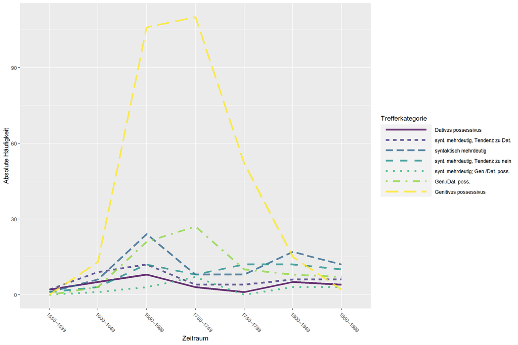

```r
p1 <- gold_cat_sum |>
  drop_na() |>
  ggplot(aes(x = Date_50, y = n,
             colour = cat, group = cat, linetype = cat)) +
  geom_line(size = 1.5, alpha = .8) +
  theme(axis.text.x = element_text(angle = -45, hjust = 0)) +
  labs(x = "Zeitraum", y = "Absolute Häufigkeit", colour = "Trefferkategorie", linetype = "Trefferkategorie") +
  scale_colour_viridis_d() +
  theme(legend.key.width = unit(3, "cm"))
p1
```

### Normalisierte Häufigkeiten

Hier werden die Häufigkeiten für jedes 50-Jahre-Intervall anhand der Gesamttokenmenge dieses Zeitraums im Korpus (s.o.) normalisiert. Da es sich bei den hier vorliegenden Daten nur um eine Stichprobe aus der Treffermenge handelt, haben wir es hier nicht mit den tatsächlichen relativen Häufigkeiten im Korpus zu tun – diese dürften noch um einiges höher liegen.

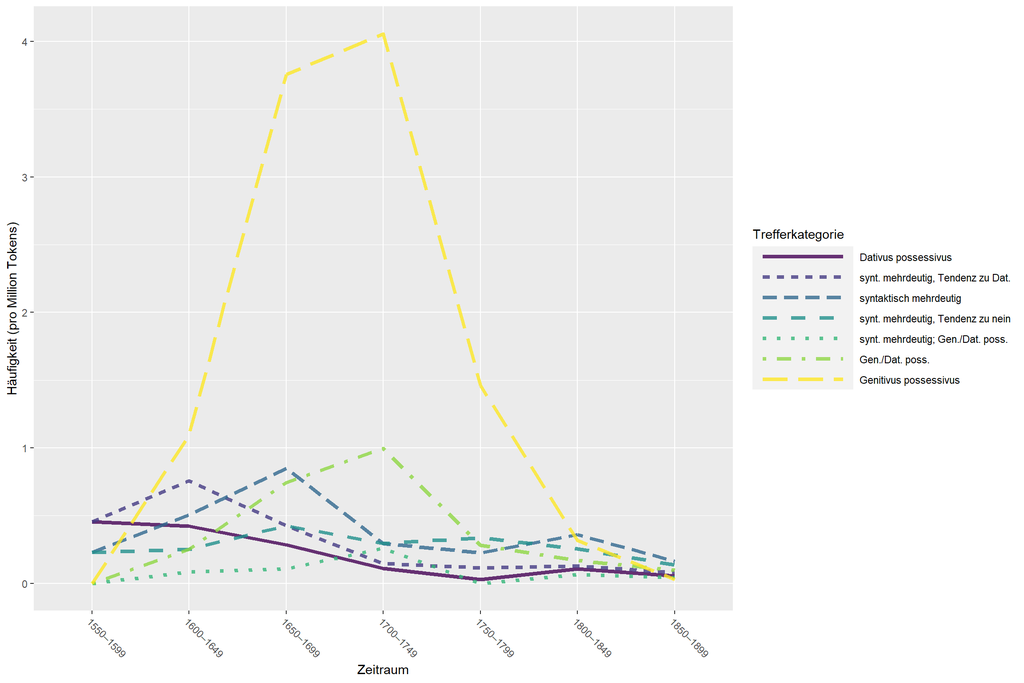

```r
p2 <- gold_cat_sum |>
  drop_na() |>
  ggplot(aes(x = Date_50, y = FpMT,
             colour = cat, group = cat, linetype = cat)) +
  geom_line(size = 1.5, alpha = .8) +
  theme(axis.text.x = element_text(angle = -45, hjust = 0)) +
  labs(x = "Zeitraum", y = "Häufigkeit (pro Million Tokens)", colour = "Trefferkategorie", linetype = "Trefferkategorie") +
  scale_colour_viridis_d() +
  theme(legend.key.width = unit(3, "cm"))

p2zoom <- gold_cat_sum |>
  drop_na() |>
  filter.(cat != "Genitivus possessivus") |>
  ggplot(aes(x = Date_50, y = FpMT,
             colour = cat, group = cat, linetype = cat)) +
  geom_line(size = 1.5, alpha = .8) +
  theme(axis.text.x = element_text(angle = -45, hjust = 0)) +
  labs(x = "Zeitraum", y = "Häufigkeit (pro Million Tokens)", colour = "Trefferkategorie", linetype = "Trefferkategorie") +
  scale_colour_viridis_d() +
  theme(legend.key.width = unit(3, "cm"))

p2
```

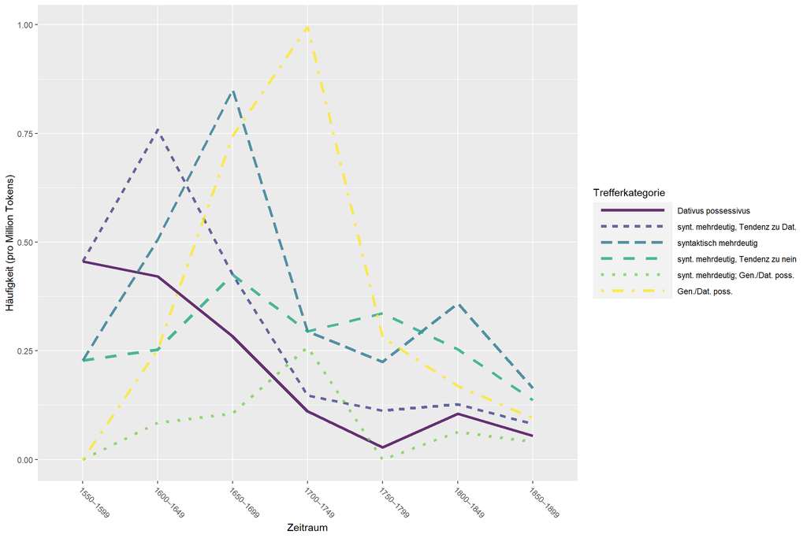

```r
p2zoom
```

Die zweite Graphik ist eine Wiederholung der ersten, nur ohne possessive Genitive, was die Häufigkeiten der anderen Formen im Zeitverlauf hoffentlich deutlicher hervortreten lässt.

Die Beleglage in der zweiten Hälfte des 16. Jahrhunderts sollte allerdings auch nicht überinterpretiert werden – dafür ist das Korpus in dieser Zeit schlicht zu klein.

### Nach Genus des (möglichen) Possessors

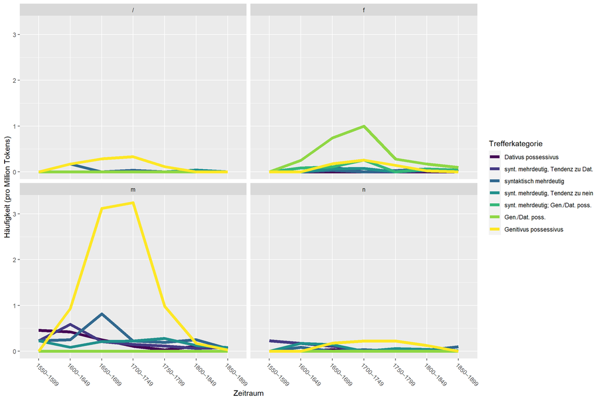

```r
gold_cat_gen_sum <- gold2 |>
  mutate.(cat = factor(cat,
                       levels = c("dp", "dpe", "aj", "a", "an",
                                  "agp/dp", "gp/dp", "gpe/dpe",
                                  "agp", "gp", "gpe"),
                       labels = c("Dativus possessivus",
                                  "Dativus possessivus",#"Dat. poss. mit Ellipse",
                                  "synt. mehrdeutig, Tendenz zu Dat.",#"synt. mehrdeutig, Tendenz zu Dat. poss.",
                                  "syntaktisch mehrdeutig",
                                  "synt. mehrdeutig, Tendenz zu nein",#"synt. mehrdeutig, Tendenz zu nein",
                                  "synt. mehrdeutig; Gen./Dat. poss.",
                                  "Gen./Dat. poss.",
                                  "Gen./Dat. poss.",#"Gen./Dat. poss. mit Ellipse",
                                  "Genitivus possessivus",#"synt. mehrdeutig, evtl. Gen. poss.",
                                  "Genitivus possessivus",
                                  "Genitivus possessivus"#"Gen. poss. mit Elipse"
                                  )),
          genus_possessor = factor(genus_possessor)) |>
  dplyr::count(Date_50, cat, genus_possessor, .drop = FALSE)

gold_cat_gen_sum <- gold_cat_gen_sum |>
  left_join.(cnts3, by = "Date_50") |>
  mutate.(FpMT = n / Count * 1e6)

gold_cat_gen_sum |>
  drop_na() |>
  ggplot(aes(x = Date_50, y = FpMT,
             colour = cat, group = cat)) +
  geom_line(size = 2) +
  theme(axis.text.x = element_text(angle = -45, hjust = 0)) +
  labs(x = "Zeitraum", y = "Häufigkeit (pro Million Tokens)", colour = "Trefferkategorie") +
  scale_color_viridis_d() +
  facet_wrap(~ genus_possessor)
```

Nur Maskulina und Feminina:

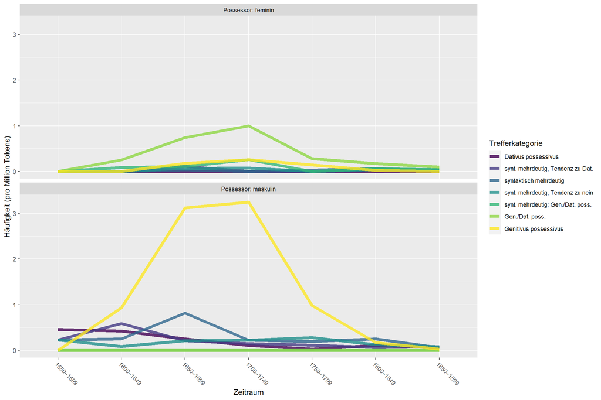

```r
gold_cat_gen_sum |>
  filter(genus_possessor %in% c("m", "f")) |>
  mutate(genus_possessor = factor(genus_possessor, labels = c("Possessor: feminin", "Possessor: maskulin"))) |>
  drop_na() |>
  ggplot(aes(x = Date_50, y = FpMT,
             colour = cat, group = cat)) +
  geom_line(size = 2, alpha = .8) +
  theme(axis.text.x = element_text(angle = -45, hjust = 0)) +
  labs(x = "Zeitraum", y = "Häufigkeit (pro Million Tokens)", colour = "Trefferkategorie") +
  scale_color_viridis_d() +
  facet_wrap(vars(genus_possessor), nrow = 2)
```

### Nach Genres

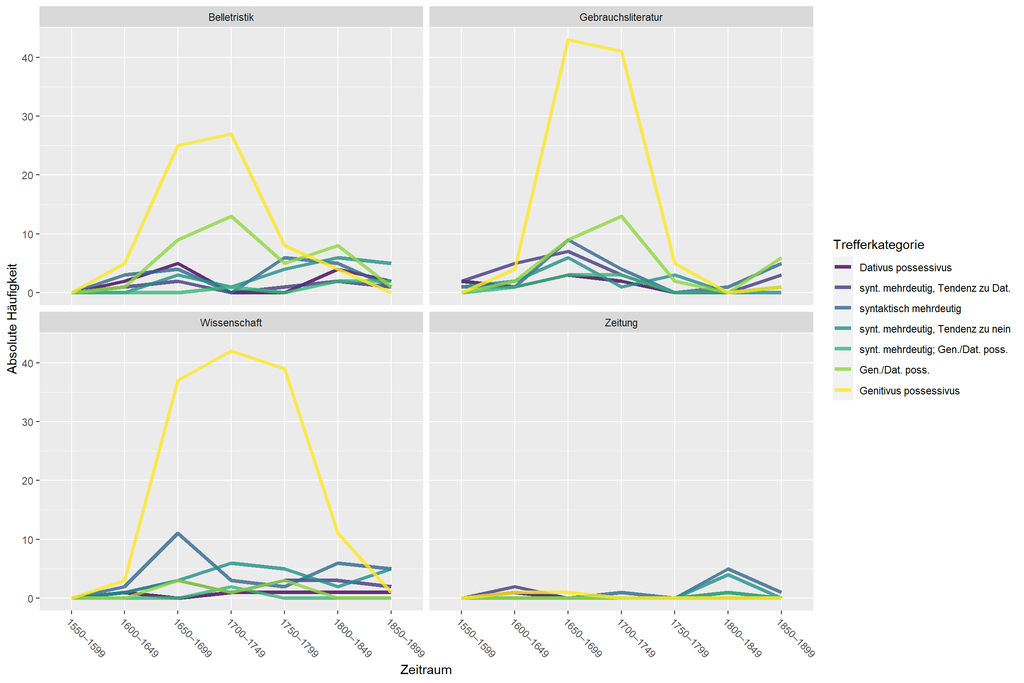

```r
gold_cat_genre_sum <- gold2 |>
  mutate.(cat = factor(cat,
                       levels = c("dp", "dpe", "aj", "a", "an",
                                  "agp/dp", "gp/dp", "gpe/dpe",
                                  "agp", "gp", "gpe"),
                       labels = c("Dativus possessivus",
                                  "Dativus possessivus",#"Dat. poss. mit Ellipse",
                                  "synt. mehrdeutig, Tendenz zu Dat.",#"synt. mehrdeutig, Tendenz zu Dat. poss.",
                                  "syntaktisch mehrdeutig",
                                  "synt. mehrdeutig, Tendenz zu nein",#"synt. mehrdeutig, Tendenz zu nein",
                                  "synt. mehrdeutig; Gen./Dat. poss.",
                                  "Gen./Dat. poss.",
                                  "Gen./Dat. poss.",#"Gen./Dat. poss. mit Ellipse",
                                  "Genitivus possessivus",#"synt. mehrdeutig, evtl. Gen. poss.",
                                  "Genitivus possessivus",
                                  "Genitivus possessivus"#"Gen. poss. mit Elipse"
                                  )),
          First_genre = factor(First_genre),
          genus_possessor = factor(genus_possessor)) |>
  dplyr::count(Date_50, cat, First_genre, .drop = FALSE) |>
  left_join.(cnts2) |>
  mutate.(Count = replace_na(Count, 0),
          FpMT = n / Count * 1e6)

gold_cat_genre_sum |>
  drop_na() |>
  ggplot(aes(x = Date_50, y = n, colour = cat, group = cat)) +
  geom_line(size = 1.5, alpha = .8) +
  theme(axis.text.x = element_text(angle = -45, hjust = 0)) +
  labs(x = "Zeitraum", y = "Absolute Häufigkeit", colour = "Trefferkategorie") +
  scale_colour_viridis_d() +
  facet_wrap(vars(First_genre))
```

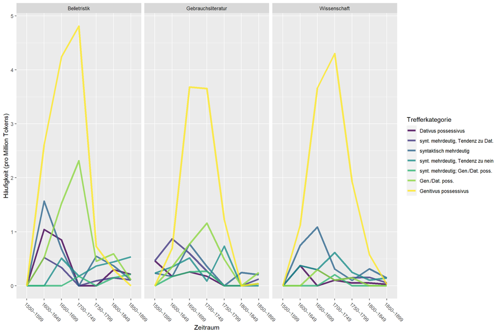

```r
gold_cat_genre_sum |>
  drop_na() |>
  filter.(First_genre != "Zeitung") |>
  ggplot(aes(x = Date_50, y = FpMT, colour = cat, group = cat)) +
  geom_line(size = 1.5, alpha = .8) +
  theme(axis.text.x = element_text(angle = -45, hjust = 0)) +
  labs(x = "Zeitraum", y = "Häufigkeit (pro Million Tokens)", colour = "Trefferkategorie") +
  scale_colour_viridis_d() +
  facet_wrap(vars(First_genre))
```

Für die normalisierten Häufigkeiten wurde das Zeitungsgenre aufgrund der geringen Trefferzahlen ausgelassen.

Dass possessive Dative und syntaktisch ambige Formen in der zweiten Hälfte des 16. Jahrhunderts nur in der Gebrauchsliteratur vorkommen, liegt lediglich daran, dass aus dieser Zeitspanne keine anderen Genres im DTA vertreten sind.

Danach kommen possessive Dative in allen drei Genres vor, am häufigsten in der Belletristik – wo sie auch im 19. Jahrhundert noch einmal ein kurzes Revival erleben, überwiegend in wörtlicher Rede, was wohl der Charakterisierung der Figuren dienen dürfte.

Possessive Genitive kommen ebenfalls in allen drei Genres vor, wobei ihr Aufstieg und Fall in der Belletristik besonders ausgeprägt erscheint.

### Nach Belebtheit des (möglichen) Possessors

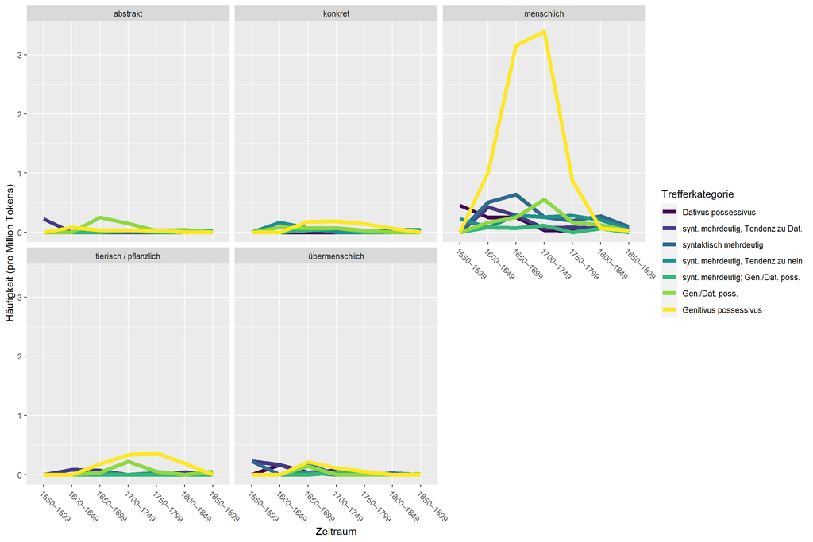

```r
gold_cat_ani_sum <- gold2 |>
  mutate.(cat = factor(cat,
                       levels = c("dp", "dpe", "aj", "a", "an",
                                  "agp/dp", "gp/dp", "gpe/dpe",
                                  "agp", "gp", "gpe"),
                       labels = c("Dativus possessivus",
                                  "Dativus possessivus",#"Dat. poss. mit Ellipse",
                                  "synt. mehrdeutig, Tendenz zu Dat.",#"synt. mehrdeutig, Tendenz zu Dat. poss.",
                                  "syntaktisch mehrdeutig",
                                  "synt. mehrdeutig, Tendenz zu nein",#"synt. mehrdeutig, Tendenz zu nein",
                                  "synt. mehrdeutig; Gen./Dat. poss.",
                                  "Gen./Dat. poss.",
                                  "Gen./Dat. poss.",#"Gen./Dat. poss. mit Ellipse",
                                  "Genitivus possessivus",#"synt. mehrdeutig, evtl. Gen. poss.",
                                  "Genitivus possessivus",
                                  "Genitivus possessivus"#"Gen. poss. mit Elipse"
                                  )),
          genus_possessor = factor(genus_possessor),
          animacy_possessor = factor(animacy_possessor,
                                     levels = c("abstrakt",
                                                "konkret",
                                                "konkret (Körperteil)",
                                                "konkret (Ort)",
                                                "menschlich",
                                                "menschlich (Kollektivum)",
                                                "pflanzlich",
                                                "pflanzlich (Kollektivum)",
                                                "tierisch",
                                                "tierisch (Kollektivum)",
                                                "übermenschlich",
                                                "übermenschlich (negativ)",
                                                "übermenschlich (positiv)"
                                     ),
                                     labels = c("abstrakt",
                                                "konkret",
                                                "konkret",
                                                "konkret",
                                                "menschlich",
                                                "menschlich",
                                                "tierisch / pflanzlich",
                                                "tierisch / pflanzlich",
                                                "tierisch / pflanzlich",
                                                "tierisch / pflanzlich",
                                                "übermenschlich",
                                                "übermenschlich",
                                                "übermenschlich")
                                     )) |>
  dplyr::count(Date_50, cat, animacy_possessor, .drop = FALSE)

gold_cat_ani_sum <- gold_cat_ani_sum |>
  left_join.(cnts3, by = "Date_50") |>
  mutate.(FpMT = n / Count * 1e6)

gold_cat_ani_sum |>
  drop_na() |>
  ggplot(aes(x = Date_50, y = FpMT,
             colour = cat, group = cat)) +
  geom_line(size = 2) +
  theme(axis.text.x = element_text(angle = -45, hjust = 0)) +
  labs(x = "Zeitraum", y = "Häufigkeit (pro Million Tokens)", colour = "Trefferkategorie") +
  scale_color_viridis_d() +
  facet_wrap(~ animacy_possessor)
```

Diese Graphiken sind leider nicht sehr übersichtlich. Hier deshalb noch einmal die Anteile der Belebtheitsstufen pro Belegkategorie (mit absoluten Häufigkeiten über den jeweiligen Säulen):

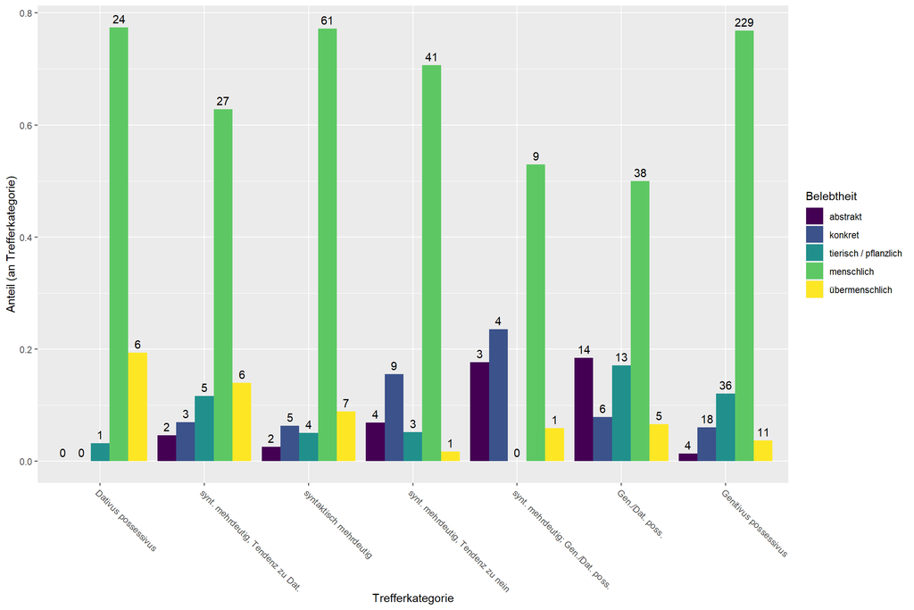

```r
gold_ani <- gold |>
  filter.(!cat %chin% c("n", "na")) |>
  mutate.(cat = factor(cat,
                       levels = c("dp", "dpe", "aj", "a", "an",
                                  "agp/dp", "gp/dp", "gpe/dpe",
                                  "agp", "gp", "gpe"),
                       labels = c("Dativus possessivus",
                                  "Dativus possessivus",#"Dat. poss. mit Ellipse",
                                  "synt. mehrdeutig, Tendenz zu Dat.",#"synt. mehrdeutig, Tendenz zu Dat. poss.",
                                  "syntaktisch mehrdeutig",
                                  "synt. mehrdeutig, Tendenz zu nein",#"synt. mehrdeutig, Tendenz zu nein",
                                  "synt. mehrdeutig; Gen./Dat. poss.",
                                  "Gen./Dat. poss.",
                                  "Gen./Dat. poss.",#"Gen./Dat. poss. mit Ellipse",
                                  "Genitivus possessivus",#"synt. mehrdeutig, evtl. Gen. poss.",
                                  "Genitivus possessivus",
                                  "Genitivus possessivus"#"Gen. poss. mit Elipse"
                                  )),
          animacy_possessor = factor(animacy_possessor,
                                     levels = c("abstrakt",
                                                "konkret",
                                                "konkret (Körperteil)",
                                                "konkret (Ort)",
                                                "menschlich",
                                                "menschlich (Kollektivum)",
                                                "pflanzlich",
                                                "pflanzlich (Kollektivum)",
                                                "tierisch",
                                                "tierisch (Kollektivum)",
                                                "übermenschlich",
                                                "übermenschlich (negativ)",
                                                "übermenschlich (positiv)"
                                     ),
                                     labels = c("abstrakt",
                                                "konkret",
                                                "konkret",
                                                "konkret",
                                                "menschlich",
                                                "menschlich",
                                                "tierisch / pflanzlich",
                                                "tierisch / pflanzlich",
                                                "tierisch / pflanzlich",
                                                "tierisch / pflanzlich",
                                                "übermenschlich",
                                                "übermenschlich",
                                                "übermenschlich")
                                     ) |>
            fct_relevel("menschlich", after = 3)) |>
  dplyr::count(cat, animacy_possessor, .drop = FALSE)

gold_ani |>
  drop_na() |>
  mutate.(Anteil = n / sum(n), .by = cat) |>
  ggplot(aes(x = cat, y = Anteil,
             fill = animacy_possessor)) +
  geom_col(position = "dodge") +
  geom_text(aes(label = n), position = position_dodge(width = .9), vjust = -.5) +
  theme(axis.text.x = element_text(angle = -45, hjust = 0)) +
  labs(x = "Trefferkategorie", y = "Anteil (an Trefferkategorie)", fill = "Belebtheit") +
  scale_fill_viridis_d()
```

Für uns eindeutige possessive Dative weisen in der Stichprobe allesamt einen belebten Possessor auf. Auch sonst dominieren belebte Erstglieder, bei den weniger klaren Fällen kommen allerdings auch häufiger konkrete und sogar einige abstrakte vor.

Beim possessiven Genitiv gibt es interessanterweise auch einige Fälle abstrakter Possessoren:

```r
gold |>
  filter.(cat %in% c("gp", "gpe") & animacy_possessor == "abstrakt") |>
  pull(sentence)
```

```
[1] "Nichts als unheilsame Noth , Nichts als Tod , Und --->der Lüste ihr<--- Gehecke , Und der Sünden Eyter-Stöcke , Und der Glieder Sterb-Gebot ."
[2] "In diser Geschicht ist sich so wol zuverwunderen über --->deß Glücks sein<--- anverwandte Wanckelmuth / als über die grosse Lieb deß Cardinalis Grimani gegen seinen Vattern ."
[3] "Ottomar empfieng ihn mit einer Sanftheit , die man nur in heftigen Karakteren in so unwiderstehlichem Grade findet , und sagte mit erhaben-leiser Stimme : \" er feiere den Todestag aller Jahrszeiten und heute wäre --->des Nachsommers seiner<--- . \""
[4] "--->Des Himmels sein<--- Boot / die Sterne samt der Henne /(kenne /"
```

### Nach Belebtheit des (möglichen) Possessums

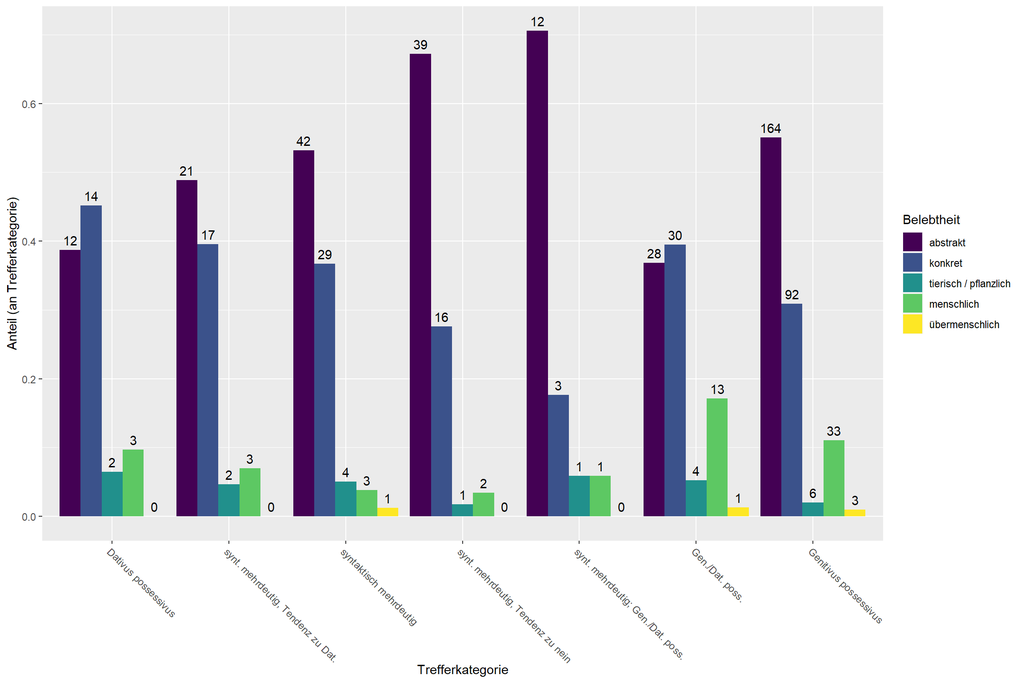

```r
gold_ani2 <- gold |>
  filter.(!cat %chin% c("n", "na")) |>
  mutate.(cat = factor(cat,
                       levels = c("dp", "dpe", "aj", "a", "an",
                                  "agp/dp", "gp/dp", "gpe/dpe",
                                  "agp", "gp", "gpe"),
                       labels = c("Dativus possessivus",
                                  "Dativus possessivus",#"Dat. poss. mit Ellipse",
                                  "synt. mehrdeutig, Tendenz zu Dat.",#"synt. mehrdeutig, Tendenz zu Dat. poss.",
                                  "syntaktisch mehrdeutig",
                                  "synt. mehrdeutig, Tendenz zu nein",#"synt. mehrdeutig, Tendenz zu nein",
                                  "synt. mehrdeutig; Gen./Dat. poss.",
                                  "Gen./Dat. poss.",
                                  "Gen./Dat. poss.",#"Gen./Dat. poss. mit Ellipse",
                                  "Genitivus possessivus",#"synt. mehrdeutig, evtl. Gen. poss.",
                                  "Genitivus possessivus",
                                  "Genitivus possessivus"#"Gen. poss. mit Elipse"
                                  )),
          animacy_possessum = factor(animacy_possessum,
                                     levels = c("abstrakt",
                                                "konkret",
                                                "konkret (Körperteil)",
                                                "konkret (Ort)",
                                                "menschlich",
                                                "menschlich (Kollektivum)",
                                                "pflanzlich",
                                                "pflanzlich (Kollektivum)",
                                                "tierisch",
                                                "tierisch (Kollektivum)",
                                                "übermenschlich",
                                                "übermenschlich (negativ)",
                                                "übermenschlich (positiv)"
                                     ),
                                     labels = c("abstrakt",
                                                "konkret",
                                                "konkret",
                                                "konkret",
                                                "menschlich",
                                                "menschlich",
                                                "tierisch / pflanzlich",
                                                "tierisch / pflanzlich",
                                                "tierisch / pflanzlich",
                                                "tierisch / pflanzlich",
                                                "übermenschlich",
                                                "übermenschlich",
                                                "übermenschlich")
                                     ) |>
            fct_relevel("menschlich", after = 3)) |>
  dplyr::count(cat, animacy_possessum, .drop = FALSE)

gold_ani2 |>
  drop_na() |>
  mutate.(Anteil = n / sum(n), .by = cat) |>
  ggplot(aes(x = cat, y = Anteil,
             fill = animacy_possessum)) +
  geom_col(position = "dodge") +
  geom_text(aes(label = n), position = position_dodge(width = .9), vjust = -.5) +
  theme(axis.text.x = element_text(angle = -45, hjust = 0)) +
  labs(x = "Trefferkategorie", y = "Anteil (an Trefferkategorie)", fill = "Belebtheit") +
  scale_fill_viridis_d()
```

Auffällig ist hier die umso stärkere Tendenz zum konkreten oder belebten Possessum, je klarer ein possessiver Dativ vorliegt. Dies gilt auch für die kasusambigen Formen, weniger ausgeprägt allerdings für possessive Genitive.

Für die weitere Forschung dürfte es interessant sein, die Abstrakta genauer zu bestimmen. So haben wir bspw. Wörter wie *Seele* oder *Verstand* als abstrakt kategorisiert, die, wie uns scheint, eine ähnliche Nähe zu Personen aufweisen wie konkrete Körperteile. Auch deverbale Substantive, die beobachtbare Tätigkeiten bezeichnen (wie *Gang* oder *Schluchzen*) sind wohl als deutlich weniger abstrakt einzustufen als etwa *Freiheit* oder *Eigentum*.

Vorstellbar wären bspw. Unterkategorien wie diese:

- abstrakt (Eigenschaft): *Frömmigkeit*, *Ehre*, *Ruf*, *Masse*
- abstrakt (wahrnehmbare Tätigkeit): *Lauf*, *Arbeit*, *Gesang*
- abstrakt (Innenleben): *Seele*, *Gedanken*, *Liebe*, *Begierde*

## Literatur

Cohen, Jacob. 1968. „Weighted kappa: Nominal scale agreement provision for scaled disagreement or partial credit“. *Psychological Bulletin* 70 (4): 213–20.

Fleiss, Joseph L., Jacob Cohen, und Brian S. Everitt. 1969. „Large sample standard errors of kappa and weighted kappa“. *Psychological Bulletin* 72 (5): 323–27.

Lindner-Bornemann, Bettina, und Andreas Blombach. 2023. „„Ach [...] was wars so dunkel in dem Wolf seinem Leib!“ Zur diachronen Entwicklung des possessiven Dativs“. In *Historische (Morpho-)Syntax des Deutschen*, herausgegeben von Alexander Lasch, Kerstin Roth, und Dominik Hetjens. Jahrbuch für Germanistische Sprachgeschichte 14. Berlin, New York: De Gruyter.

## Fußnoten

[^1]: Das Label `"na"` wurde vorrangig von einem der beiden Annotatoren vergeben, um Fälle zu markieren, die zwar eindeutig keinen possessiven Dativ enthalten (i.d.R. aufgrund der Verbvalenz), in denen semantisch aber dennoch eine possessive Lesart möglich ist. Eine gründliche Sichtung dieser Annotationen, um sie für künftige Forschung nutzbar zu machen, steht noch aus.